# Reproducible Research / Week 2 / Course Project 1

Jpund

2022-10-14

This document helps understand the analysis of data coming from the use of a personal activity monitoring device. This device collects data at 5 minute intervals through out the day. The data consists of two months of data from an anonymous individual collected during the months of October and November, 2012 and include the number of steps taken in 5 minute intervals each day.

### 1. Code for reading in the dataset and/or processing the data

```r
wd <- getwd()
download.file("https://d396qusza40orc.cloudfront.net/repdata%2Fdata%2Factivity.zip", destfile = paste0(wd,"/output.zip"))
unzip(zipfile = "output.zip")
data <- read.csv(file = "activity.csv", header = TRUE)
summary(data)
```

```
##      steps            date              interval
##  Min.   :  0.00   Length:17568       Min.   :   0.0
##  1st Qu.:  0.00   Class :character   1st Qu.: 588.8
##  Median :  0.00   Mode  :character   Median :1177.5
##  Mean   : 37.38                      Mean   :1177.5
##  3rd Qu.: 12.00                      3rd Qu.:1766.2
##  Max.   :806.00                      Max.   :2355.0
##  NA's   :2304
```

```r
data$date <- as.Date(data$date, format="%Y-%m-%d")
```

### 2. What is mean total number of steps taken per day?

## - Calculate the total number of steps taken per day.

```r
perday  <- aggregate(data$steps ~ data$date, data=data, FUN=sum)
names(perday) <- c("date","stepsperday")
head(perday)
```

```
##         date stepsperday
## 1 2012-10-02         126
## 2 2012-10-03       11352
## 3 2012-10-04       12116
## 4 2012-10-05       13294
## 5 2012-10-06       15420
## 6 2012-10-07       11015
```

```r
library(ggplot2)

g <- ggplot(perday, aes(y = stepsperday, x = date)) +
        geom_bar(stat="identity") +
        scale_x_date(date_labels = "%Y-%m-%d", date_breaks = "1 month") +
        labs(x = "Date", y = "Steps per day")
print(g)
```

[output not shown]

## - Calculate and report the mean and median of the total number of steps taken per day

```r
mean_steps <- mean(perday$stepsperday, na.rm = TRUE)
median_steps <- median(perday$stepsperday, na.rm = TRUE)
print(mean_steps)
```

```
## [1] 10766.19
```

```r
print(median_steps)
```

```
## [1] 10765
```

### 3. What is the average daily activity pattern?

Make a time series plot of the 5-minute interval and the average number of steps taken, averaged across all days.

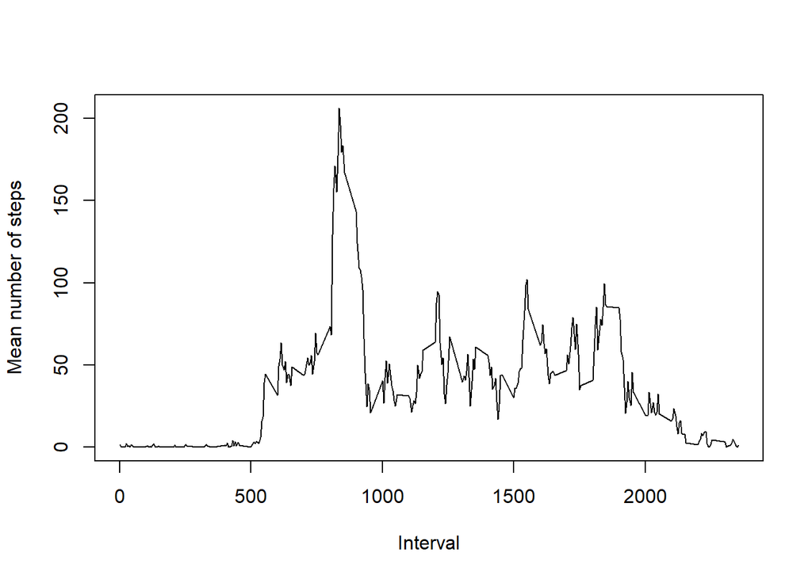

```r
#calculate the average number of steps taken for each 5-minutes interval across all days
perinterval  <- aggregate(data$steps ~ data$interval, data=data, FUN=mean)
names(perinterval) <- c("interval","mean_steps_per_interval")

f  <- plot(perinterval$interval,perinterval$mean_steps_per_interval, type="l",
           xlab = "Interval", ylab="Mean number of steps")
```

```r
print(f)
```

Which 5-minute interval, on average across all the days in the dataset, contains the maximum number of steps?

```r
perinterval[which.max(perinterval$mean_steps_per_interval),]
```

```
##     interval mean_steps_per_interval
## 104      835                206.1698
```

It is the interval 835.

## 4. Imputing missing values

- Calculate and report the total number of missing values in the dataset.

```r
sum(is.na.data.frame(data))
```

```
## [1] 2304
```

## - Devise a strategy for filling in all of the missing values in the dataset.

The mean number of steps for the whole period in the same interval as the NA value interval will be used. It is more likely that this person does the same thing at the same interval everyday than during the rest of the day.

```r
#thanks to summary(), we know there are only missing values in the steps column

data$nass <- is.na(data$steps)
data$nona <- data$steps

for (i in 1:17568){
        if (data[i,4]==TRUE){
           z=data[i,3]
           mean_row=data[data$interval==z,]

           data[i,1] <- mean(mean_row[,5], na.rm = TRUE)
        }
}

datanona <- data.frame(data$nona, data$date, data$interval)
names(datanona) <- c("nona","data","interval")
```

## - Calculate and report the mean and median total number of steps taken per day.

```r
perdaynona  <- aggregate(data$nona ~ data$date, data=data, FUN=sum)
names(perdaynona) <- c("date","stepsperday")

mean_stepsnona <- mean(perdaynona$stepsperday, na.rm = TRUE)
median_stepsnona <- median(perdaynona$stepsperday, na.rm = TRUE)

j <- ggplot(perdaynona, aes(y = stepsperday, x = date)) +
        geom_bar(stat="identity") +
        scale_x_date(date_labels = "%Y-%m-%d", date_breaks = "1 month") +
        labs(x = "Date", y = "Steps per day")
print(j)
```

[output not shown]

## - Do these values differ from the estimates from the first part of the assignment? What is the impact of imputing missing data on the estimates of the total daily number of steps?

```r
print(mean_steps-mean_stepsnona)
```

```
## [1] 0
```

```r
print(median_steps-median_stepsnona)
```

```
## [1] 0
```

```r
b <- ggplot(perdaynona, aes(y = stepsperday, x = date)) +
        geom_bar(stat="identity") +
        scale_x_date(date_labels = "%Y-%m-%d", date_breaks = "1 month") +
        labs(x = "Date", y = "Steps per day")
print(b)
```

[output not shown]

```r
library(timeDate)
library(RQuantLib)
```

```r
data$weekday <- isBusinessDay(calendar="WeekendsOnly", dates=data$date)

perinterval  <- aggregate(data$steps ~ data$interval+data$weekday, data=data, FUN=mean)
names(perinterval) <- c("interval","truwee","mean_steps_per_interval")

k=ggplot(perinterval, aes(interval, mean_steps_per_interval)) + geom_point() + facet_grid(. ~ truwee)
```

## - All of the R code needed to reproduce the results (numbers, plots, etc.) in the report

```r
data <- read.csv(file = "activity.csv", header = TRUE)
summary(data)
data$date <- as.Date(data$date, format="%Y-%m-%d")

perday  <- aggregate(data$steps ~ data$date, data=data, FUN=sum)
names(perday) <- c("date","stepsperday")
head(perday)

library(ggplot2)

g <- ggplot(perday, aes(y = stepsperday, x = date)) +
        geom_bar(stat="identity") +
        scale_x_date(date_labels = "%Y-%m-%d", date_breaks = "1 month") +
        labs(x = "Date", y = "Steps per day")
print(g)
```

[output not shown]

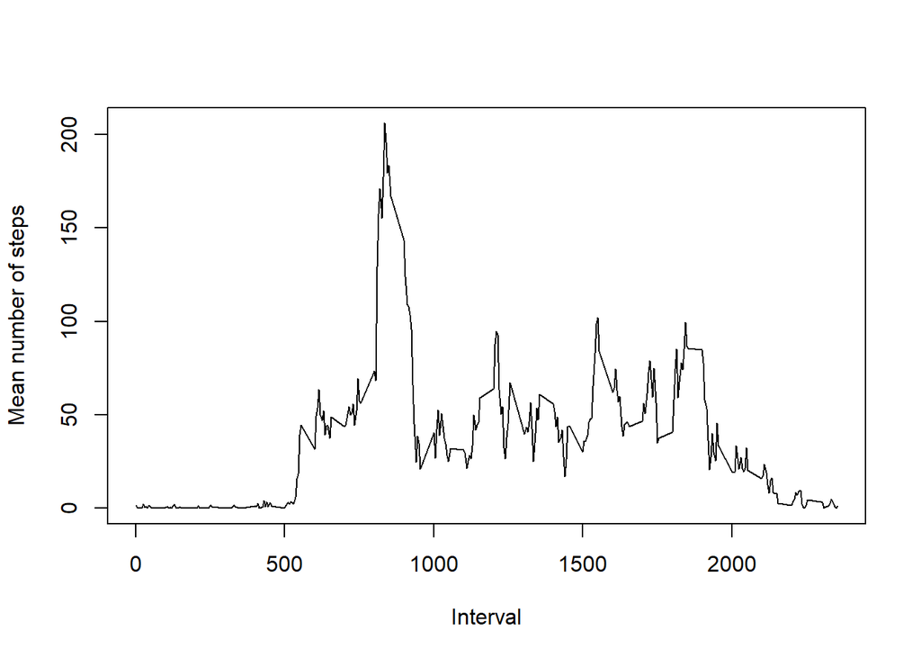

```r
mean_steps <- mean(perday$stepsperday, na.rm = TRUE)
median_steps <- median(perday$stepsperday, na.rm = TRUE)
print(mean_steps)
print(median_steps)

#calculate the average number of steps taken for each 5-minutes interval across all days
perinterval  <- aggregate(data$steps ~ data$interval, data=data, FUN=mean)
names(perinterval) <- c("interval","mean_steps_per_interval")

f  <- plot(perinterval$interval,perinterval$mean_steps_per_interval, type="l",
           xlab = "Interval", ylab="Mean number of steps")
```

[output not shown]

```r
print(f)

perinterval[which.max(perinterval$mean_steps_per_interval),]

sum(is.na.data.frame(data))

#thanks to summary(), we know there are only missing values in the steps column

data$nass <- is.na(data$steps)
data$nona <- data$steps

for (i in 1:17568){
        if (data[i,4]==TRUE){
           z=data[i,3]
           mean_row=data[data$interval==z,]

           data[i,1] <- mean(mean_row[,5], na.rm = TRUE)
        }
}

datanona <- data.frame(data$nona, data$date, data$interval)
names(datanona) <- c("nona","data","interval")

perdaynona  <- aggregate(data$nona ~ data$date, data=data, FUN=sum)
names(perdaynona) <- c("date","stepsperday")

mean_stepsnona <- mean(perdaynona$stepsperday, na.rm = TRUE)
median_stepsnona <- median(perdaynona$stepsperday, na.rm = TRUE)

j <- ggplot(perdaynona, aes(y = stepsperday, x = date)) +
        geom_bar(stat="identity") +
        scale_x_date(date_labels = "%Y-%m-%d", date_breaks = "1 month") +
        labs(x = "Date", y = "Steps per day")
print(j)
```

[output not shown]

```r
print(mean_steps-mean_stepsnona)
print(median_steps-median_stepsnona)

b <- ggplot(perdaynona, aes(y = stepsperday, x = date)) +
        geom_bar(stat="identity") +
        scale_x_date(date_labels = "%Y-%m-%d", date_breaks = "1 month") +
        labs(x = "Date", y = "Steps per day")
print(b)
```

[output not shown]

```r
library(timeDate)
library(RQuantLib)
data$weekday <- isBusinessDay(calendar="WeekendsOnly", dates=data$date)

perinterval  <- aggregate(data$steps ~ data$interval+data$weekday, data=data, FUN=mean)
names(perinterval) <- c("interval","truwee","mean_steps_per_interval")

k=ggplot(perinterval, aes(interval, mean_steps_per_interval)) + geom_point() + facet_grid(. ~ truwee)
```